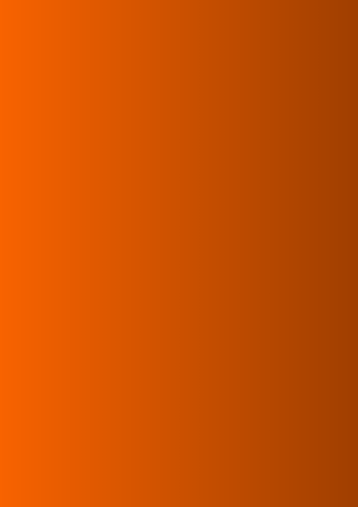

World Journal of

*Gastroenterology*

*World J Gastroenterol* 2019 July 21; 25(27): 3468-3663

**ISSN 1007-9327 (print)**

**ISSN 2219-2840 (online)**

Published by Baishideng Publishing Group Inc

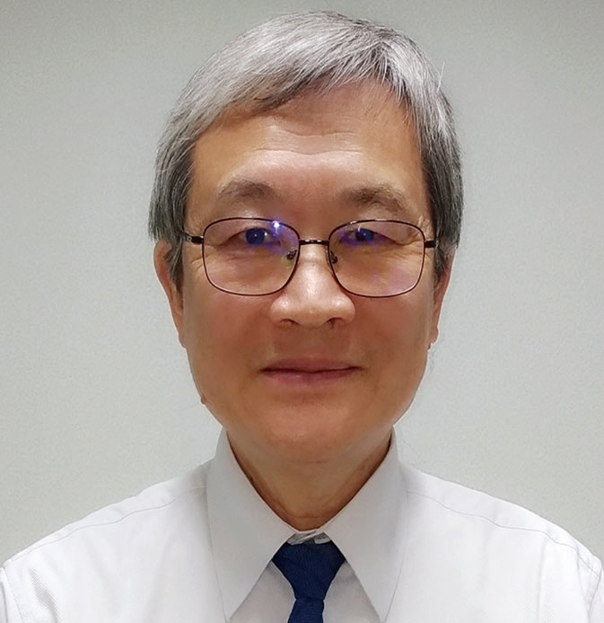

W J G

*World Journal of*

*Gastroenterology*

**Contents**

**Weekly Volume 25 Number 27 July 21, 2019**

**OPINION REVIEW**

**3468**

Stricter national standards are required for credentialing of endoscopic-retrograde-cholangiopan-

creatography in the United States

*Cappell MS, Friedel DM*

**3484**

Colorectal peritoneal metastases: Optimal management review

*Sánchez-Hidalgo JM, Rodríguez-Ortiz L, Arjona-Sánchez Á, Rufián-Peña S, Casado-Adam Á, Cosano-Álvarez A,*

*Briceño-Delgado J*

**REVIEW**

**3503**

Eosinophils in the gastrointestinal tract and their role in the pathogenesis of major colorectal disorders

*Loktionov A*

**3527**

Immune suppression in chronic hepatitis B infection associated liver disease: A review

*Li TY, Yang Y, Zhou G, Tu ZK*

**MINIREVIEWS**

**3538**

Device-assisted enteroscopy: A review of available techniques and upcoming new technologies

*Schneider M, Höllerich J, Beyna T*

**3546**

Identifying high-risk individuals for gastric cancer surveillance from western and eastern perspectives:

Lessons to learn and possibility to develop an integrated approach for daily practice

*Quach DT, Hiyama T, Gotoda T*

**3563**

Is the treatment outcome of hepatocellular carcinoma inferior in elderly patients?

*Chu KKW, Chok KSH*

**ORIGINAL ARTICLE**

**Basic Study**

**3572**

Mucosal healing progression after acute colitis in mice

*Vidal-Lletjós S, Andriamihaja M, Blais A, Grauso M, Lepage P, Davila AM, Gaudichon C, Leclerc M, Blachier F, Lan A*

**3590**

Lingguizhugan decoction attenuates diet-induced obesity and hepatosteatosis *via* gut microbiota

*Liu MT, Huang YJ, Zhang TY, Tan LB, Lu XF, Qin J*

**Retrospective Cohort Study**

**3607**

Intermediate-advanced hepatocellular carcinoma in Argentina: Treatment and survival analysis

*Piñero F, Marciano S, Fernández N, Silva J, Anders M, Zerega A, Ridruejo E, Romero G, Ameigeiras B, D’Amico C, Gaite L,*

*Bermúdez C, Reggiardo V, Colombato L, Gadano A, Silva M*

WJG

https://www.wjgnet.com

July 21, 2019

Volume 25

Issue 27

I

**Contents**

*World Journal of Gastroenterology*

**Volume 25 Number 27 July 21, 2019**

**Retrospective Study**

**3619**

Quantitative diffusion-weighted magnetic resonance enterography in ileal Crohn's disease: A systematic

analysis of intra and interobserver reproducibility

*Yu H, Shen YQ, Tan FQ, Zhou ZL, Li Z, Hu DY, Morelli JN*

**SYSTEMATIC REVIEWS**

**3634**

Bioartificial liver support systems for acute liver failure: A systematic review and meta-analysis of the

clinical and preclinical literature

*He YT, Qi YN, Zhang BQ, Li JB, Bao J*

**META-ANALYSIS**

**3649**

Immunotherapy with dendritic cells and cytokine-induced killer cells for hepatocellular carcinoma: A meta-

analysis

*Cao J, Kong FH, Liu X, Wang XB*

WJG

https://www.wjgnet.com

July 21, 2019

Volume 25

Issue 27

II

**Contents**

*World Journal of Gastroenterology*

**Volume 25 Number 27 July 21, 2019**

**ABOUT COVER**

Editorial board member of *World Journal of Gastroenterology*, Dar-In Tai, MD,

PhD, Attending Doctor, Chief Doctor, Professor, Department of

Gastroenterology and Hepatology, Chang Gung Memorial Hospital, Taipei

105, Taiwan

**AIMS AND SCOPE**

*World Journal of Gastroenterology* (*World J Gastroenterol*, *WJG*, print ISSN 1007-

9327, online ISSN 2219-2840, DOI: 10.3748) is a peer-reviewed open access

journal. The *WJG* Editorial Board consists of 701 experts in gastroenterology

and hepatology from 58 countries.

The primary task of *WJG* is to rapidly publish high-quality original

articles, reviews, and commentaries in the fields of gastroenterology,

hepatology, gastrointestinal endoscopy, gastrointestinal surgery,

hepatobiliary surgery, gastrointestinal oncology, gastrointestinal radiation

oncology, *etc*. The *WJG* is dedicated to become an influential and

prestigious journal in gastroenterology and hepatology, to promote the

development of above disciplines, and to improve the diagnostic and

therapeutic skill and expertise of clinicians.

**INDEXING/ABSTRACTING**

The *WJG* is now indexed in Current Contents<sup>®</sup>/Clinical Medicine, Science Citation

Index Expanded (also known as SciSearch<sup>®</sup>), Journal Citation Reports<sup>®</sup>, Index

Medicus, MEDLINE, PubMed, PubMed Central, and Scopus. The 2019 edition of

Journal Citation Report<sup>®</sup> cites the 2018 impact factor for *WJG* as 3.411 (5-year impact

factor: 3.579), ranking *WJG* as 35<sup>th</sup> among 84 journals in gastroenterology and

hepatology (quartile in category Q2). CiteScore (2018): 3.43.

**RESPONSIBLE EDITORS FOR**

**THIS ISSUE**

**Responsible Electronic Editor:** *Yu-Jie Ma*

**Proofing Production Department Director:** *Yun-Xiaojian Wu*

**NAME OF JOURNAL**

*World Journal of Gastroenterology*

**ISSN**

ISSN 1007-9327 (print) ISSN 2219-2840 (online)

**LAUNCH DATE**

October 1, 1995

**FREQUENCY**

Weekly

**EDITORS-IN-CHIEF**

Subrata Ghosh, Andrzej S. Tarnawski

**EDITORIAL BOARD MEMBERS**

http://www.wjgnet.com/1007-9327/editorialboard.htm

**EDITORIAL OFFICE**

Ze-Mao Gong, Director

**PUBLICATION DATE**

July 21, 2019

**COPYRIGHT**

© 2019 Baishideng Publishing Group Inc

**INSTRUCTIONS TO AUTHORS**

https://www.wjgnet.com/bpg/gerinfo/204

**GUIDELINES FOR ETHICS DOCUMENTS**

https://www.wjgnet.com/bpg/GerInfo/287

**GUIDELINES FOR NON-NATIVE SPEAKERS OF ENGLISH**

https://www.wjgnet.com/bpg/gerinfo/240

**PUBLICATION MISCONDUCT**

https://www.wjgnet.com/bpg/gerinfo/208

**ARTICLE PROCESSING CHARGE**

https://www.wjgnet.com/bpg/gerinfo/242

**STEPS FOR SUBMITTING MANUSCRIPTS**

https://www.wjgnet.com/bpg/GerInfo/239

**ONLINE SUBMISSION**

https://www.f6publishing.com

© 2019 Baishideng Publishing Group Inc. All rights reserved. 7041 Koll Center Parkway, Suite 160, Pleasanton, CA 94566, USA

E-mail: bpgoffice@wjgnet.com https://www.wjgnet.com

WJG

https://www.wjgnet.com

July 21, 2019

Volume 25

Issue 27

III

W J G

*World Journal of*

*Gastroenterology*

Submit a Manuscript: https://www.f6publishing.com

*World J Gastroenterol* 2019 July 21; 25(27): 3634-3648

DOI: 10.3748/wjg.v25.i27.3634

ISSN 1007-9327 (print) ISSN 2219-2840 (online)

*SYSTEMATIC REVIEWS*

**Bioartificial liver support systems for acute liver failure: A**

**systematic review and meta-analysis of the clinical and preclinical**

**literature**

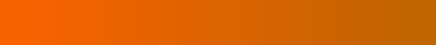

Yu-Ting He, Ya-Na Qi, Bing-Qi Zhang, Jian-Bo Li, Ji Bao

**ORCID number:** Yu-Ting He

(0000-0003-4107-2118); Ya-Na Qi

(0000-0003-4287-7348); Bing-Qi

Zhang (0000-0001-5146-8592); Jian-

Bo Li (0000-0001-8430-392X); Ji Bao

(0000-0001-8413-3270).

**Author contributions:** He YT and

Qi YN contributed equally to the

work and are co-first authors. He

YT and Bao J designed the

research; He YT, Qi YN, and Zhang

BQ contributed to literature

selection and data extraction; He

YT, Qi YN, Bao J, and Li JB

contributed to analysis and

interpretation of the data; He YT

and Qi YN drafted the original

manuscript; Bao J and Li JB revised

the article; All authors have read

the final article and approved the

publication of the manuscript.

**Conflict-of-interest statement:** The

authors have no conflict of

interests to disclose.

**PRISMA 2009 Checklist statement:**

The authors have read the PRISMA

2009 Checklist, and the manuscript

was prepared and revised

according to the PRISMA 2009

Checklist.

**Open-Access:** This article is an

open-access article which was

selected by an in-house editor and

fully peer-reviewed by external

reviewers. It is distributed in

accordance with the Creative

Commons Attribution Non

Commercial (CC BY-NC 4.0)

license, which permits others to

distribute, remix, adapt, build

upon this work non-commercially,

and license their derivative works

**Yu-Ting He, Bing-Qi Zhang, Ji Bao,** Laboratory of Pathology, Key Laboratory of Transplant

Engineering and Immunology, NHC, West China Hospital, Sichuan University, Chengdu

610041, Sichuan Province, China

**Ya-Na Qi,** Chinese Evidence-based Medicine Center, West China Hospital, Sichuan University,

Chengdu 610041, Sichuan Province, China

**Jian-Bo Li,** Department of Liver Surgery, West China Hospital, Sichuan University, Chengdu

610041, Sichuan Province, China

**Corresponding author:** Ji Bao, PhD, Associate Professor, Laboratory of Pathology, Key

Laboratory of Transplant Engineering and Immunology, NHC, West China Hospital, Sichuan

University, No. 37, Guoxue Alley, Wuhou District, Chengdu 610041, Sichuan Province,

China. baoji@scu.edu.cn

**Telephone:** +86-18980606618

**Fax:** +86-28-85164033

**Abstract**

*BACKGROUND*

Acute liver failure (ALF) has a high mortality varying from 80% to 85% with

rapid progress in multi-organ system failure. Bioartificial liver (BAL) support

systems have the potential to provide temporary support to bridge patients with

ALF to liver transplantation or spontaneous recovery. In the past decades, several

BAL support systems have been conducted in clinical trials. More recently,

concerns have been raised on the renovation of high-quality cell sources and

configuration of BAL support systems to provide more benefits to ALF models in

preclinical experiments.

*AIM*

To investigate the characteristics of studies about BAL support systems for ALF,

and to evaluate their effects on mortality.

*METHODS*

Eligible clinical trials and preclinical experiments on large animals were

identified on Cochrane Library, PubMed, and EMbase up to March 6, 2019. Two

reviewers independently extracted the necessary information, including key BAL

indicators, survival and indicating outcomes, and adverse events during

treatment. Descriptive analysis was used to identify the characteristics of the

included studies, and a meta-analysis including only randomized controlled trial

WJG

https://www.wjgnet.com

July 21, 2019

Volume 25

Issue 27

3634

on different terms, provided the

original work is properly cited and

the use is non-commercial. See:

http://creativecommons.org/licen

ses/by-nc/4.0/

**Manuscript source**: Invited

manuscript

**Received:** March 20, 2019

**Peer-review started:** March 20, 2019

**First decision:** March 27, 2019

**Revised:** May 3, 2019

**Accepted:** May 31, 2019

**Article in press:** June 1, 2019

**Published online:** July 21, 2019

**P-Reviewer:** Kayaalp C,

R<sup>Milovanovic T, Nacif LS, Williams</sup>

**S-Editor:** Ma RY

**L-Editor:** Wang TQ

**E-Editor:** Wu YXJ

[figure not shown]

(RCT) studies was done to calculate the overall effect of BAL on mortality among

humans and large animals, respectively.

*RESULTS*

Of the 30 selected studies, 18 were clinical trials and 12 were preclinical

experiments. The meta-analysis result suggested that BAL might reduce

mortality in ALF in large animals, probably due to the recent improvement of

BAL, including the type, cell source, cell mass, and bioreactor, but seemed

ineffective for humans [BAL *vs* control: relative risk (95% confidence interval),

0.27 (0.12-0.62) for animals and 0.72 (0.48-1.08) for humans]. Liver and renal

functions, hematologic and coagulative parameters, encephalopathy index, and

neurological indicators seemed to improve after BAL, with neither meaningful

adverse events nor porcine endogenous retrovirus infection.

*CONCLUSION*

BAL may reduce the mortality of ALF by bridging the gap between preclinical

experiments and clinical trials. Clinical trials using improved BAL must be

designed scientifically and conducted in the future to provide evidence for

transformation.

**Key words:** Bioartificial liver; Acute liver failure; Preclinical experiment; Clinical trial;

Meta-analysis

**©The Author(s) 2019.** Published by Baishideng Publishing Group Inc. All rights reserved.

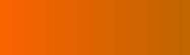

**Core tip:** This systematic review and meta-analysis included a large number of studies

about clinical trials and preclinical experiments of bioartificial liver (BAL) support

systems for treating patients and large animal models with acute liver failure. We

summarized the characteristics of studies, BAL, and outcomes in all the studies and

compared the pooled effect by meta-analysis including only randomized controlled trial

studies regarding mortality after BAL among humans and large animals, respectively.

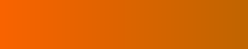

**Citation:** He YT, Qi YN, Zhang BQ, Li JB, Bao J. Bioartificial liver support systems for acute

liver failure: A systematic review and meta-analysis of the clinical and preclinical literature.

*World J Gastroenterol* 2019; 25(27): 3634-3648

**URL**: https://www.wjgnet.com/1007-9327/full/v25/i27/3634.htm

**DOI**: https://dx.doi.org/10.3748/wjg.v25.i27.3634

**INTRODUCTION**

Acute liver failure (ALF) is characterized by an acute episode of liver dysfunction in

individuals without underlying chronic liver diseases, sometimes causing a rapid

onset of encephalopathy and coagulopathy followed by multiorgan system failure.

Patients with ALF have a high mortality ranging from 80% to 85%, approaching 90%

among those with severe fulminant hepatic failure (FHF)<sup>[</sup><sup>1</sup><sup>]</sup>. The most effective

treatment method for patients with ALF is liver transplantation, as it has increased the

5-year survival rate by 75%<sup>[</sup><sup>2</sup><sup>]</sup>. Although some patients might recover spontaneously,

many would die during waiting for a compatible donor because of aggressive

deterioration of liver function or development of cerebral edema, intracranial

hypertension, and even irreversible brain damage. Thus, a liver support system must

be developed to maintain a viable status of these patients prior to the transplantation.

During the past decades, several artificial devices for removing toxins from

patients’ blood through filtration and adsorption have improved clinical status in

some cases. However, a meta-analysis of six randomized controlled trials (RCTs)

concluded that artificial liver support systems might not reduce the mortality in

ALF<sup>[</sup><sup>3</sup><sup>]</sup>. Moreover, the newly developed bioartificial liver (BAL) support systems that

incorporate a hepatoma cell line or primary hepatocytes into a bioreactor when

processing blood or plasma proved meaningful for prolonging the survival time of

ALF animals in preclinical trials. Several types have been applied for the treatment of

patients with ALF in phase I studies or controlled clinical trials, and improved

neurological status and liver and renal functions, thus bridging to transplantation or

WJG

https://www.wjgnet.com

July 21, 2019

Volume 25

Issue 27

He YT *et al.* Bioartificial liver for acute liver failure

3635

spontaneous recovery<sup>[</sup><sup>4</sup><sup>-</sup><sup>7</sup><sup>]</sup>. However, the survival outcome and adverse effects of such

alternative methods are controversial<sup>[</sup><sup>3</sup><sup>,</sup><sup>8</sup><sup>]</sup>.

In addition, the BAL has various types with different cell sources, cell mass, and

culture methods, as well as architectural design such as the bioreactor, scaffold, and

separation, which might be associated with the effect and safety of the BAL in treating

ALF<sup>[</sup><sup>9</sup><sup>]</sup>. Furthermore, the BAL has been modified and renovated in preclinical

experiments on large animals but has not been used in clinical trials<sup>[</sup><sup>10</sup><sup>-</sup><sup>12</sup><sup>]</sup>, which caused

a significant gap between clinical and preclinical studies.

One objective of our study was to investigate the characteristics of studies about

BAL for ALF in both clinical trials and recent preclinical experiments on large

animals. In particular, we looked at key indicators of the BAL, survival outcome, and

adverse events regarding the treatment. Another objective was to evaluate the pooled

effect of the BAL on mortality by conducting a meta-analysis of randomized

controlled studies stratified among patients with ALF and large animals.

**MATERIALS AND METHODS**

This study was constructed following the Preferred Reporting Items for Systematic

Reviews and Meta-Analysis (PRISMA) guidelines. The protocol has been registered in

PROSPERO, an international prospective register of systematic reviews (Registration

number: CRD42019133215).

*Inclusion and exclusion criteria*

We included studies about any of the BAL for ALF, including all clinical trials, case

reports, and RCTs in patients with ALF and preclinical experiments in large animals

(monkeys, pigs, and dogs) published in the past 10 years. The language was limited to

English.

The exclusion criteria were as follows: (1) Not focusing on the outcome of BAL, or

the ALF group could not be separated from the other study populations such as

patients with acute-on-chronic liver failure; (2) Duplicates of previous publications;

(3) Based on incomplete data; and (4) Reviews, meta-analyses, comments, guidelines,

letters, editorial articles, and project or conference summaries. If more than one study

by the same author using the same data was published, either the study with the

largest sample size or the most recently published study was included.

*Literature search and selection*

By using a searching strategy and filter that combined keywords or subjects about

BAL and ALF, which had been pre-tested and improved repeatedly, we searched the

Cochrane Library, PubMed, and EMbase to identify eligible articles till March 6, 2019

according to the inclusion and exclusion criteria, by setting the following key

elements (Patients: ALF; Intervention: BAL; Comparison: None; Outcome: including

but not limited to mortality, bridging time, liver and renal function; keywords used

for literature search are shown in Supplementary material). Literature about

preclinical experiments in large animals was limited to papers published in the past

10 years. The references used in the eligible articles were also reviewed to examine

other potential sources.

Teams of paired reviewers who were trained and knowledgeable about the study

screened the literature independently. We screened the title and keywords first and

excluded unqualified studies according to the predefined criteria. Then, we read the

abstracts and full texts carefully to further exclude unqualified literature. The decision

to exclude studies was determined by two reviewers. Inconsistent results were

resolved either by discussion or decided by a third reviewer. Finally, the remaining

studies were enrolled to be reviewed and analyzed. The flow chart of the study

selection is shown in Figure 1.

*Data extraction*

We extracted the following information from each eligible article: (1) Basic

information of the included studies, including the publication year, title of the article,

journal along with impact factor in 2018, country of the first author, study setting,

study type (clinical trial, case report, or preclinical experiment), and data sources (full

text and abstract); (2) Detailed information of clinical trials in humans, including the

type of BAL [*e.g*., HepatAssist, extracorporeal liver assist device (ELAD), academic

medical center (AMC)-BAL, modular extracorporeal liver support (MELS), novel

bioartificial liver support system (BLSS), radial-flow bioreactor (RFB)-BAL, and

hybrid bioartificial liver (HBAL)], whether hybrid or not, cell sources (*e.g*., porcine

hepatocytes, C3A cells, or primary human hepatocytes), cell mass, sample size, ALF

subtype [fulminant hepatic failure (FHF) or primary nonfunction (PNF)], age and sex

WJG

https://www.wjgnet.com

July 21, 2019

Volume 25

Issue 27

He YT *et al.* Bioartificial liver for acute liver failure

3636

**Figure 1**

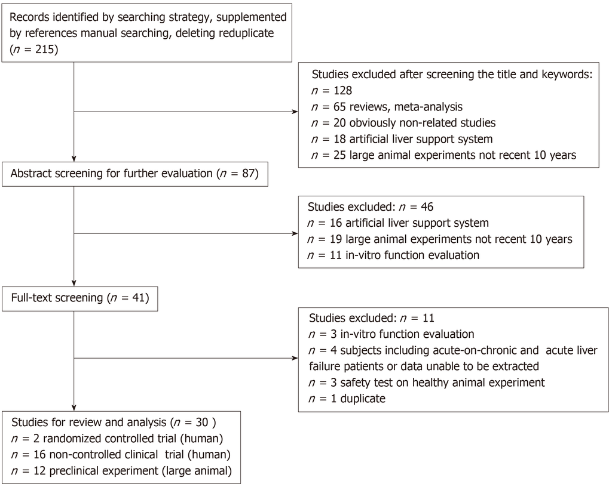

**Figure 1 Flow chart of study selection.**

of subjects, disease etiology [*e.g*., PNF, viral, indeterminate, autoimmune,

Acetaminophen (AO), and ischemic], BAL treatment time, outcomes (*i.e*., bridging

time, orthotopic liver transplantation, death events, and recovery), follow-up time,

stable or unstable hemodynamics, effects on liver and renal functions, hematologic

and coagulative parameters, encephalopathy index, neurological status, adverse

events during treatment (*e.g*., transitory hypotension), and porcine endogenous

retrovirus (PERV) test result; (3) data of preclinical experiment on large animals,

including animal species (*e.g*., pig, canine, and monkey), number of animals, sex

(female and male), weight (kg), inducer of acute liver failure (*e.g*., D-galactosamine,

hepatic artery ligation, surgical ligation of all blood flow to the liver, α-amanitin, and

lipopolysaccharide), type of BAL (*e.g*., FBBAL, HBAL, HBALSS, SRBAL, hiHep-BAL,

and UCLBAL), cell sources (*e.g*., alginate-chitosan encapsulated primary porcine

hepatocytes, co-cultured pig hepatocytes, bone marrow mesenchymal stem cells,

human hepatic CL-1 cells grown in microgravity culture, HiHeps, and three-

dimensional HepG2-cell spheroids), cell mass, bioreactor (*e.g*., choanoid fluidized bed

bioreactor, multi-layer ﬂat-plate bioreactor anionic resin adsorption column,

fluidized-bed bioreactor, perfusion bioreactor, spheroid reservoir, and packed-bed

bioreactor), treatment time, survival time or rate at a specific time point, other effects

such as ammonia level, and PERV test result.

For data extraction and scoring, paired reviewers conducted the survey

independently on the basis of the literature database and recorded the necessary

information. The results of the paired reviewers were cross-checked, and

disagreements were resolved by discussion or decided by a third reviewer.

*Statistical analysis*

We conducted description analyses of the study characteristics of clinical trials and

preclinical experiments on large animals by using the absolute numbers and

percentages of the qualitative variables, and mean [standard deviation (SD)] or

median (percentile) of the quantitative data. The bias risk of the included RCT studies

was assessed according to the Cochrane assessment method for RCTs, while risk of

non-RCT studies was assessed according to the Newcastle-Ottawa Quality

Assessment Scale for cohort studies.

By selecting clinical RCTs and preclinical RCT experiments with survival outcome

(death event) recorded at a specific time, we combined the effect of selected studies on

the relative ratio (RR) scale by performing a meta-analysis with a random effect model

WJG

https://www.wjgnet.com

July 21, 2019

Volume 25

Issue 27

He YT *et al.* Bioartificial liver for acute liver failure

3637

and assigning weights according to the estimated variance. The heterogeneity of the

included studies was also tested, with Q-test significance (*P <* 0.05) or *I2 >* 50%

indicating that heterogeneity existed between studies. The overall RR and 95%

confidence interval (CI) were calculated. We also conducted sensitivity analyses to

examine the impact of using alternative effect measures (odds ratio *vs* relative ratio),

pooling methods [Peto *vs* Mantel-Hanszel (M-H)], and statistical models (fixed- *vs*

random-effects). Begg’s funnel plot was also used to evaluate the publication bias.

All the statistical analyses were performed with SPSS 23.0 (IBM Corp. Armonk, NY,

United States) and Review Manager 5.3 (RevMan, the Cochrane Collaboration,

Oxford, England).

**RESULTS**

We identified 215 studies preliminarily, and then excluded 67 unrelated or ineligible

articles, 34 articles about artificial liver support system, 14 articles about *in vitro*

function evaluation, 1 duplicate article, 4 articles with unavailable data, and 65

reviews. We finally included 30 articles in the analyses, of which 18 were human

clinical trials<sup>[</sup><sup>6</sup><sup>,</sup><sup>7</sup><sup>,</sup><sup>13</sup><sup>-</sup><sup>28</sup><sup>]</sup> (only 2 were RCT studies<sup>[</sup><sup>6</sup><sup>,</sup><sup>7</sup><sup>]</sup>) and 12 were preclinical experiments

in large animals<sup>[</sup><sup>5</sup><sup>,</sup><sup>10</sup><sup>-</sup><sup>12</sup><sup>,</sup><sup>29</sup><sup>-</sup><sup>36</sup><sup>]</sup>.

preclinical experiments in large animals in the recent 10 years accounted for 40% of

the articles (12/30). The median (P25-P75) impact factor (IF) of the journals was 4.04

(2.60-9.20), with 8 articles having an IF < 3 and 5 having an IF > 10. Approximately

two-thirds of the studies were conducted by authors in the United States (11/30) and

China (8/30). One RCT study was done in England and published in *Hepatology* in

1996<sup>[</sup><sup>7</sup><sup>]</sup> while the other one was performed in 11 United States and 9 European sites by

United States researchers and published in *Annals of Surgery* in 2004<sup>[</sup><sup>6</sup><sup>]</sup>. More than one-

third (12/30) of the studies were about hybrid support systems (*e.g*., HBAL, MELS,

HBALSS, and HepatAssist), distributed in 9 clinical trial studies and 3 preclinical

experimental studies. The available data that we analyzed were mostly from full texts

(29/30), and 1 abstract of clinical trial was also included considering the limited

number of eligible studies in humans and the availability of valuable information in

the abstract (as shown in Supplemental Table 1).

*Characteristics of the BAL, subjects, outcomes, and adverse events in the clinical*

*trials*

From the 18 clinical trials, 332 patients with ALF were included, with 295 cases of FHF

subtypes and 37 cases of PNF subtypes. The mean age was 35.4 years, and females

accounted for 69.4% of the patients according to the reported data. Most of the disease

etiologies were indeterminate (103 cases), viruses (45 cases), and AO (33 cases). The

types of BAL included HepatAssist (6 cases), ELAD (3 cases), AMC-BAL (2 cases),

MELS (2 cases), BLSS (1 case), RFB-BAL (1 case), HBAL (1 case), Lifeliver (1 case), and

BAL (1 case), and in one case the BAL type was unclear; of these 9 were hybrids and 8

were non-hybrids. Most of the cells were sourced from porcine hepatocytes (14/18),

followed by C3A cells (3/18) and primary human hepatocytes (1/18). The mean cell

mass was approximately 9 × 10<sup>9</sup> (Table 1).

The mean treatment time was around 25 h. Among the 317 reported patients, 201

received orthotopic liver transplant (OLT) and 57 recovered without OLT. The mean

survival rate in the OLT group was 93%, with the follow-up period ranging from 7 d

to 62 mo. Hemodynamics were stable in all patients. These results show that BAL

improved liver and renal functions in all the patients, except 3 with PNF<sup>[</sup><sup>6</sup><sup>,</sup><sup>14</sup><sup>,</sup><sup>15</sup><sup>]</sup>, in terms

of the different biochemical parameters, with decreased ammonia, bilirubin, and

transaminase levels in 12, 12, and 10 studies, respectively. Other meaningful

indicators were reduced, including lactate ALB, BUN, and creatinine levels. By

examining prothrombin time (PT), international normalized ratio, or other

parameters, 9 studies found improvements in hematological and coagulative status.

Ten of 12 reported studies showed an improvement in encephalopathy index.

Thirteen of 16 reported studies showed improvements in neurological indicators,

showing decreased intracranial pressure (ICP) and increased cerebral perfusion

pressure, Glasgow coma score, and comprehensive level of consciousness score. In 3

studies on ALF subtypes, the encephalopathy index and neurological indicators

showed improvements in patients with FHF but not in patients with PNF<sup>[</sup><sup>6</sup><sup>,</sup><sup>14</sup><sup>,</sup><sup>15</sup><sup>]</sup>.

However, one case report of a patient with PNF showed improvement in the

neurological status with a change in coma stage from IV to I after BAL treatment<sup>[</sup><sup>22</sup><sup>]</sup>

(Table 2).

WJG

https://www.wjgnet.com

July 21, 2019

Volume 25

Issue 27

He YT *et al.* Bioartificial liver for acute liver failure

3638

3639

July 21, 2019 **|**Volume 25**|**Issue 27**|**

**WJG** **|**https://www.wjgnet.com

**Table 1 Characteristics of bioartificial liver support system and subjects of clinical trials**

**ID**

**Publication year**

**Type of trial**

**BAL system**

**Subject**

**Type**

**Hybrid**

**Cell**

**Mass**

**Sample No.**

**Subtype**

**Age**

**Sex**

**Disease etiology**

1

1994

Non-controlled trial

HepatAssist

Yes

Porcine hepatocytes

6 × 10

9

7

FHF 6

10-58

4M:3F

PNF 1 ; Virus 1; AO 2; Indeterminate 3

PNF 1

2

1997

Non-controlled trial

HepatAssist

Yes

Porcine hepatocytes

5 × 10

9

21

FHF 18

36.1 ± 3.4

7M:11F

Virus 4; Indeterminate 8; AO 4; Ischemic 2

PNF 3

48.3 ± 11.2 1M:2F

Virus 1; Indeterminate 1; Autoimmune 1

3

2010

Non-controlled trial

HepatAssist

Yes

Porcine hepatocytes

5 × 10

9

18

FHF 15

10-56

10M;5F

Indeterminate 7; Virus 3; AO 4; Ischemic 1

PNF 3

26-58

1M:2F

Indeterminate 1; Virus 1; Autoimmune 1;

4

2002

Non-controlled trial

HepatAssist

Yes

Porcine hepatocytes

5 × 10

9

10

FHF 10

31

4M:6F

Indeterminate 6; Virus 2; Wilson 1;

Pyrazinamide 1

5

1994

Non-controlled trial

ELAD

No

C3A cells

200 g

11

FHF 10

38.5 ± 18.1 5M:6F

Idiopathic 1; Virus 3; AO 2; INH 1; FIAU 3; Anhepatic 1

PNF 1

6

2002

Non-controlled trial

ELAD

No

C3A cells

300-400g

5

FHF 5

22.2 ± 9.4

2M:3F

L-asparaginase toxicity 1; Indeterminate 3; Autoimmune 1

7

2002

Phase I trial

AMC-BAL

No

Porcine hepatocytes

11.9 × 10

9

7

FHF 7

34.3 ± 15.2 2M:5F

Virus 4; AFLP 1; Indeterminate 2

8

2003

Case report

AMC-BAL

No

Porcine hepatocytes

10 × 10

9

1

FHF

35

F

Virus 1

9

1996

Non-controlled trial

NR

No

Porcine hepatocytes

5 × 10

9

12

FHF 11

37.2 ± 15.5 6M:6F

Indeterminate 4; AO 2; Virus 3; Ischemic Failure 1;

Autoimmune 1; PNF 1

PNF 1

10

2003

Phase I trial

MELS

Yes

Porcine hepatocytes;

non-parenchymal cells

(1.8-4.4) ×

10

10

8

FHF 8

34.3

1M:7F

Rug-related 2; Virus 3; Indeterminate 3

11

2003

Case report

MELS

Yes

Human hepatocytes

470 g

1

PNF

26

F

Intoxication with amanita phalloides

12

2002

Case report

BLSS

No

Porcine

70-100 g

1

FHF

41

F

Indeterminate 1

hepatocytes

13

2002

Non-controlled trial

RFB-BAL

No

Porcine

200-230 g

7

FHF 4

37.4 ± 18.4 5M:2F

Virus 3; PNF 3; Liver trauma 1

hepatocytes

PNF 3

14

2003

Non-controlled trial

HBAL

Yes

Porcine

1.0 × 10

9

12

FHF 12

41.8 ± 13.0 9M:3F

Virus 12

hepatocytes

15

1999

Non-controlled trial

HepatAssis

Yes

Porcine

5 × 10

9

8

FHF 8

33.4 ± 11.0 1M:7F

AO 8

hepatocytes

16

1

2018

Phase 1/2a trial

Lifeliver

NR

Porcine

NR

8

FHF 8

NR

NR

NR

BAL

hepatocytes

spheroids

17

1996

Pilot-Controlled trial

ELAD

No

C3A cells

400 g

Group-1 17

FHF 17

30

6M:3F vs 3M:5F

2

AO 5, Virus 3, ATB 5 vs AO 6, Virus 1

2

; ATB 1

Group-2 7

FHF 7

0M:3F vs 3M:1F

2

AO 3 vs AO 3, Virus 1

2

18

2004

RCT

HepatAssist

Yes

Porcine hepatocytes

7 × 10

9

171

FHF 147

37

26M:60F vs 25M:60F

2

Known causes 83, Indeterminate 64

PNF 24

1Data from abstract;

2Intervention vs control. NA: Not applicable; NR: Not reported; Sex: Male (M) and Female (F); ELAD: Extracorporeal liver assist device; BAL: Bioartificial liver; AMC-BAL: Academic medical center bioartificial liver; MELS:

Modular extracorporeal liver support; BLSS: Novel bioartificial liver support system; RFB-BAL: Radial-flow bioreactor bioartificial liver; HBAL: Hybrid bioartificial liver; FBBAL: Fluidized bed bioartificial liver; HBALSS: Hybrid

bioartificial liver support system; PNF: Primary nonfunction; FHF: Fulminant hepatic failure; AO: Acetaminophen; INH: Isoniazid; FIAU: Fialuridine; AFLP: Acute fatty liver of pregnancy; ATB: Anti-tuberculous hepatotoxicity;

PERV: Porcine endogenous retrovirus; RCT: Randomized controlled trial.

He YT et al. Bioartificial liver for acute liver failure

During BAL treatment, 9 studies reported adverse events such as transient

hypotension, decreased body temperature, tachycardia, pyrexia, and hypoglycemia,

which had no clinical significance and resolved in all. PERV test results in 8 reported

studies were all negative (Table 2).

*Characteristics of the BAL, animal, and outcomes in the preclinical experiments*

*with large animals*

Of 12 studies that performed preclinical experiments with pigs (8 studies, 160

animals), monkeys (2 studies, 45 animals), and canines (2 studies, 40 animals), the

proportions of male and female animals were 45.3% (111/245) and 30.2% (74/245),

animals)<sup>[</sup><sup>36</sup><sup>]</sup>, and α-amanitin and lipopolysaccharide in 1 study (30 animals)<sup>[</sup><sup>10</sup><sup>]</sup> (Table

3).

The types of BAL included SRBAL (*n* = 3), HBAL (*n* = 2), FBBAL (*n* = 1), UCLBAL

(*n* = 1), hiHep-BAL (*n* = 1), HBALSS (*n* = 1), FBBAL (*n* = 1), and BAL (*n* = 1), using

and HiHeps (1/12), which were all cultured using modified three-dimensional

methods such as spheroids, organoid, alginate-chitosan encapsulated, and even

microgravity culture, with corresponding bioreactors such as a spheroid reservoir.

The mean cell mass was 2 × 10<sup>10</sup>, and the treatment time ranged from 3 to 24 h (mean:

9 h; Table 3).

Compared with the control group, the survival outcomes (median survival time or

survival rate) were better in the BAL group, and the biochemical metabolic function

showed improvement, especially decreased ammonia levels (10/12), bilirubin levels

(6/12), ICP (5/12), and PT (4/12). All the PERV test results were negative in reported

studies (Table 3).

*Meta-analysis of the effects of the BAL on mortality in the clinical trials and*

*preclinical experiments*

As shown in Figure 2, the overall effect of the BAL on mortality in the patients with

ALF<sup>[</sup><sup>6</sup><sup>,</sup><sup>7</sup><sup>]</sup> was insignificant [BAL 97 *vs* control 98: RR (95%CI), 0.72 (0.48-1.08)].

However, the meta-analysis of the preclinical experiments of large animals<sup>[</sup><sup>10</sup><sup>,</sup><sup>12</sup><sup>,</sup><sup>29</sup><sup>,</sup><sup>30</sup><sup>,</sup><sup>32</sup><sup>,</sup><sup>36</sup><sup>]</sup>

indicated a significant effect of the BAL [BAL 56 *vs* control 77: RR (95%CI), 0.27 (0.12-

0.62)]. The test of heterogeneity showed no significant difference between included

studies, with *I*<sup>2</sup> being 0% and 41% for human clinical studies and pre-clinical

experimental studies, respectively.

Sensitivity analyses of pooled results using an alternative effect measure (M-H OR

= 0.61, 95%CI: 0.33-1.11 for humans; OR = 0.05, 0.01-0.17 for animals), pooling method

(Peto fixed effects OR = 0.61, 95%CI: 0.34-1.11 for humans; OR = 0.07, 0.03-0.15 for

animals), and statistical model (fixed effects M-H RR = 0.72, 95%CI: 0.48-1.08 for

humans; RR = 0.24, 0.13-0.44 for animals) showed similar findings.

As shown in Supplemental Figure 1, we observed publication bias and found none

in the clinical trials, and little in the preclinical experiment studies. However, it

remains unclear because of the small number of included studies.

*Bias risk of included RCT and non-RCT studies*

By bias assessment, all the included RCT studies were regarded as low or middle-risk

overall, with 4 to 6 of 7 items listed by the Cochrane assessment standards for RCT

assessed as low risk (Supplemental Table 2). For non-RCT studies, all the clinical trials

among humans scored 5 or 6 (total score: 9), indicating a low or middle risk, while

those of pre-clinical experiments scored a little higher, with most scoring 7 or 8

(Supplemental Table 3).

**DISCUSSION**

*Main findings and interpretations*

By conducting a systematic review of 18 clinical trials and 12 preclinical experiment in

large animals, including a meta-analysis of selected studies, we suggest that the BAL

might reduce mortality from ALF in large animals, but not in humans [BAL *vs* control:

RR (95%CI), 0.27 (0.12-0.62) for animals and 0.72 (0.48-1.08) for humans], with no

heterogeneity observed between included studies. Compared with the preclinical

experiments, most of the clinical trials were conducted more than 10 years ago.

Moreover, the BAL used in large animals has undergone an obvious improvement

regarding the type, cell source, cell mass, and bioreactor. All the studies showed

improvements in liver and renal functions, hematologic and coagulative parameters,

WJG

https://www.wjgnet.com

July 21, 2019

Volume 25

Issue 27

He YT *et al.* Bioartificial liver for acute liver failure

3640

3641

July 21, 2019 **|**Volume 25**|**Issue 27**|**

**WJG****|**https://www.wjgnet.com

He YT et al. Bioartificial liver for acute liver failure

**Table 2 Outcomes and adverse events after treating by bioartificial liver support system in clinical trials**

**ID**

**Treating**

**time**

**Bridging**

**OLT**

**/total**

**SR of**

**OLT**

**SR of no**

**OLT**

**Recovery**

**without OLT**

**Follow-up**

**time**

**Hemody**

**namics**

**Liver and renal function**

**Hematologic and**

**coagulation**

**Encephalopathy**

**index**

**Neurologic**

**Adverse events**

**PERV test**

**time**

1

1.6 × 6 h

24 h

7/7

100%

NA

NA

NR

Stable

Decreased: Ammonia; transaminases

Decreased:

Fibrinogen

Improved

Decreased: ICP

None

NR

Increased: CPP

2

2.1 × 6 h

45.3 h

16/18 100%

50%

1

NR

Stable

Decreased: Ammonia; ALB;

transaminases; bilirubin; BUN; creatinine

Not improved

Improved

Decreased: ICP;

Transient hypoten-

sion

NR

Increased: CPP; GCS;

CLOCS

Increased: Glucose

1.6 × 6 h

83.0 h

3/3

100%

NA

NA

NR

Stable

Decreased: Transaminases; bilirubin; ALB Not improved

Not improved

Not improved

Increased: Glucose

3

1.8 × 6 h

38.6 h

14/15 100%

100%

1

2 m-62 m

Stable

Decreased: Ammonia; bilirubin;

transaminases; ALB; BUN; creatinine;

Not improved

Improved

Decreased: ICP;

None

Negative

5 yr

Increased: CLOCS

Increased: Glucose

1.7 × 6 h

21 h-8 d

3/3

100%

NA

NA

2 m-62 m

Stable

Not improved

Not improved

Improved

Not improved

4

1.9 × 6 h

46 h

10/10 80%

NA

NA

24.5 m

Stable

Decreased: Bilirubin; transaminases

Decreased: Pla-

telets; Fibrinogen

Improved

Increased: GCS; CLOCS

Bleeding; Transitory

hypotension

Negative

5

52.6 h

40.8 h

4/11

100%

14%

1

10 d

Stable

Improved

NR

Improved

Improved

Transitory

hypotension

NA

6

50.8 h

50.8 h

5/5

80%

NA

NA

30 d

Stable

Improved

NR

Not improved

Not improved

None

NA

7

18.9 h

NR

6/7

100%

100%

1

18 m

Stable

Decreased: Bilirubin; Ammonia

NR

NR

Improved

Transitory hypoten-

sion

Negative

18 m

8

35 h

35 h

1/1

100%

NA

NA

15 m

Stable

Decreased: Bilirubin; Ammonia; Lactate

Not improved

NR

Improved

NR

Negative

12 m

9

1.7 × 6 h

39.3 h

12/12 100%

NR

NR

NR

Stable

Decreased: Bilirubin; Ammonia; Transa-

minases;

Not improved

Improved

Decreased: ICP

None

NR

Increased: Glucose

Increased: CPP; CLOCS

10

27.3 h

NR

8/8

100%

NR

NR

3 yr

Stable

Decreased: Bilirubin; ALB

Decreased:

Platelets

Improved

NA

Decreased body

temperature

Negative

3 yr

11

79 h

79 h

1/1

100%

NR

NR

1 yr

Stable

Decreased: Lactate; BUN; creatinine

Improved

Improved

Improved

Decreased body

temperature

NA

12

12 h

7 d

NA

1

NA

1

NA

1

NA

1

7 d

Stable

Decreased: Lactate; Ammonia;

Transaminases

Improved

NR

Not improved

Hypoglycemia

NR

13

11.7 h

11.7 h

6/7

83%

0%

0

NA

Stable

Decreased: Bilirubin; Transaminase;

Ammonia; Lactate; Urea

Improved

NR

Improved

None

Negative

180 d

14

1.1 × 6 h

NR

NA

2

NA

2

NR

NR

1 m

Stable

Decreased: Bilirubin; Transaminase;

Ammonia

Improved

NR

Improved

None

NR

15

2.9 × 6 h

NR

3/8

100%

100%

5

NR

Stable

Decreased: Ammonia; Bilirubin; Transa-

minases; BUN; Creatinine

Improved

Improved

Decreased: ICP

None

NR

Increased: CLOCS

16

NR

NR

2/6

100%

75%

3

NR

NR

Decreased: Ammonia

Not improved

NR

Improved

Coagulopathy pneu-

monia, sepsis, and di-

seased progression

Negative

17

h72 (3-168)

NR

2/9 vs

2/8

3

50% vs

50%

3

6/7 vs

5/6

3

6 vs 5

3

NR

Stable

Decreased: Ammonia

Improved

NR

NR

Tachypnoeic; Tachy-

cardic; Pyrexial;Disse-

minated intravascular

coagulation

NA

1/3 vs

1/4

3

100%

vs

100%

3

0% vs

0%

3

0 vs 0

3

3642

July 21, 2019 **|**Volume 25**|**Issue 27**|**

**WJG****|**https://www.wjgnet.com

He YT et al. Bioartificial liver for acute liver failure

1Suitable liver was available for OLTx during that time;

2Simultaneous HBAL 1/7 died; nonsimultaneous HBAL 2/5 died;

3Intervention vs control. NA: Not applicable; NR: Not reported; SR: Survival rate; OLT: Orthotopic liver transplantation; ALB: Albumin; BUN: Blood urea nitroge; ICP: Intracranial pressure; CPP: Cerebral perfusion pressure;

GCS: Glasgow coma score; CLOCS: Comprehensive level of consciousness score; PERV: Porcine endogenous retrovirus.

18

17.4 h

5 d vs 3

d

3

45/85

vs

49/86

3

89% vs

80%

3

50% vs

38%

3

20 vs 14

3

30 d

Stable

Decreased: Bilirubin

Not improved

NR

Not improved

None

Negative

12 m

**Table 3 Characteristics of preclinical experiments on large animals in past 10 years**

**ID**

**Year**

**Animal**

**BAL system**

**Outcomes**

**Test for PERV**

**Species**

**No Sex Weight**

**(kg)**

**Inducer**

**Type**

**Cell**

**Mass**

**Bioreactor**

**Treatment**

**time**

**Survival**

**Other**

19

2011

Pig

30

M

10-15

D-galactosamine

FBBAL

Alginate-chitosan encapsulated

primary porcine hepatocytes

5 × 10

9

Choanoid

fluidized bed

bioreactor

6 h

Survival time:

Decreased: Lactate; Glucose

NR

BAL 72.9 ± 4.72 h

Sham BAL

54.6 ± 4.09 h

Control 54.8 ± 3.98 h

20

2012

Canine

32

NR 10-15

D-galactosamine

HBAL

Co-cultured porcine

hepatocytes and bone marrow

mesenchymal stem cells

1x 10

10

Multi-layer flat-

plate bioreactor

+ anionic resin

adsorption

column

3 h

7 day survival:

Decreased: Transaminases;

LDH; Ammonia; Bilirubin; PT

Negative 7 d

HBAL 7/8

Increased: ALB

BAL 5/8

NBAL 4/8

Control 3/8

21

2013

Pig

13

F

25-30

Hepaticartery

ligation

NA

Alginate-encapsulated

HepG2cell-spheroids

5 × 10

10 Fluidised-bed

bioreactor

7 h

Survival time:

Decreased: ICP; Ammonia;

Increased: Bilirubin; Acidosis

NR

BAL 10.5 ± 20.7 h

SBAL 8.6 ± 21.4 h

22

2014

Cynomolgus

monkey

15

M

6.5-7.0

D-galactosamine

HBALSS Human hepatic CL-1 cells

grown in microgravity culture

4 × 10

9

Perfusion

bioreactor

6 h

Survival time: 128 h

Decreased: bilirubin; TBA;

BUN; Cr; ammonia; Fischer

indices

NR

BAL 5/10

Increased: ALB

Control 0/5

23

2015

Canine

8

NR 10-13

D-galactosamine

HBAL

Co-cultured porcine

hepatocytes and bone marrow

mesenchymal cells

1 × 10

10 Multi-layer flat-

plate bioreactor

+ anionic resin

adsorption

column

6 h

1 year survival: 7/8

Decreased: Transaminases; PT;

Bilirubin; LDH; Ammonia;

Negative 1 yr

Increased: ALB

24

2015

Pig

18

F

45

D-galactosamine

SRBAL

Porcine hepatocytes spheroids

200 g

Spheroid

reservoir

24 h

Survival 90 h (%)

Decreased: Ammonia; ICP;

Brain water content

NR

ST 0/6, 0%

ST + Non-cell 1/6,17%

ST + SRBAL 5/6, 83%

25

2016

Pig

21

M

10-15

D-galactosamine

FBBAL

Alginate-chitosan encapsulated

porcine hepatocytes

5 × 10

9

Choanoid

fluidized bed

bioreactor

6 h

Survival time:

Decreased: PCs; LPCs; FAs;

SM;

NR

FBBAL 70.4 ± 11.5 h

Increased: CBAs

Sham FBBAL

51.6 ± 7.9 h

Control 49.3 ± 6.6 h

3643

July 21, 2019 **|**Volume 25**|**Issue 27**|**

**WJG****|**https://www.wjgnet.com

26

2016

Pig

20

NR 15-25

D-galactosamine

HiHep-

BAL

HiHeps

3 × 10

9

Multi-layer

radial-flow

bioreactor

3 h

Survival 7 d:

Decreased: Transaminase

Ammonia; Bilirubin; PT

NR

hiHep-BAL 7/8

Empty-BAL 1/6

No-BAL 0/6

27

2017

Pig

25

F

30-35

Surgical ligation of

all blood flow to the

liver

UCLBAL

3-dimensional (3D) HepG2-

cell spheroids

7.3 × 10

10

Fuidised bed

bioreactor

6 h

Survival time: Control-BAL

Decreased: PT; INR; ICP;

Ammonia

NR

7.04 ± 1.9 h, (n = 15)

Cell-BAL

8.21 ± 2.3 h, (n = 13)

28

2017

Pig

15

M

45-55

Complete

hepatic inflow

devascularization

NA

Ca-alginate-immobilized

hepatocyte spheroids

2 × 10

10

Packed-bed

bioreactor

12 h

Median survival time:

Decreased: Ammonia;

Creatinine ICP; BP

NR

Control 21 h (n = 5)

Increased: Urine

BAL 28.5 h (n = 5)

Cell-free BAL 21 h (n = 5)

29

2018

Rhesus

monkey

30

M

10-20

α-amanitin and

lipopolysaccharide

SRBAL

Pig hepatocyte-HUVEC

organoids

2.6 × 10

10

Spheroid

reservoir

6 h

Median survival time:

Decreased: Ammonia; Bilirubin Negative 6 h

SRBAL 12 h 336 h (n = 6)

Increased: Albumin

SRBAL 24 h 248 h (n = 6)

SRBAL 36 h 132 h (n = 6)

Sham no-cell SRBAL 12 h 90

h (n = 6)

Control 60.5 h (n = 6)

30

2019

Pig

18

F

20-30

85% hepatectomy

SRBAL

Porcine hepatocyte

200 g

Spheroid

reservoir

24 h

Survival rate at 90 h:

Decreased: Ammonia; ICP; INR NR

spheroids

SMT 0/6

SMT plus no-cell SRBAL 0/6Increased: Volume regeneration

SMT plus SRBAL (200 g) 5/6

NA: Not applicable; NR: Not reported; BAL: Bioartificial liver; Sex: Male (M) and Female (F); ELAD: Extracorporeal liver assist device; AMC-BAL: Academic medical center bioartificial liver; MELS: Modular extracorporeal liver

support; BLSS: Novel bioartificial liver support system; RFB-BAL: Radial-flow bioreactor bioartificial liver; HBAL: Hybrid bioartificial liver; FBBAL: Fluidized bed BAL; HBALSS: Hybrid bioartificial liver support system; SRBAL:

Spheroid reservoir bioartificial liver; hiHep: Human-induced hepatocytes; CBAs: Conjugated bile acids; PCs: Phosphatidylcholines; LPCs: Lysophosphatidylcholines; FAs: Fatty acids; SM: Sphingomyelin; ICP: Intracranial

pressure; ALB: Albumin; PT: Prothrombin time; INR: International normalized ratio; PERV: Porcine endogenous retrovirus.

He YT et al. Bioartificial liver for acute liver failure

**Figure 2**

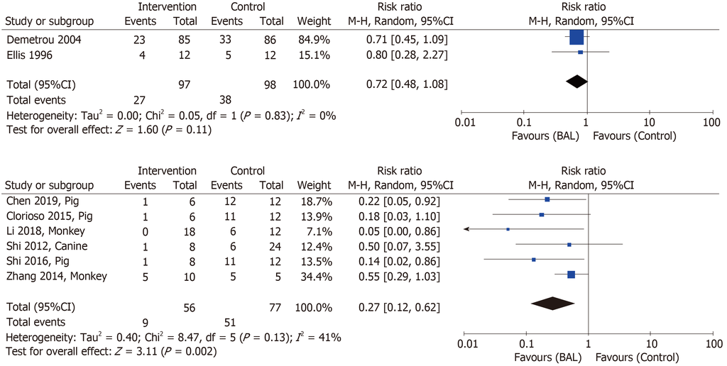

**Figure 2 Effect of bioartificial liver support systems on mortality in acute liver failure humans and large animals.** The randomized controlled trials for meta-

analysis included 2 clinical trials and 6 preclinical experiments with death events (or survival rate) recorded between 90 h to 7d after application of bioartificial liver

support systems. M-H: Mantel-Hanszel; BAL: Bioartificial Liver; CI: Confidence interval.

encephalopathy index, and neurological indicators after the treatment with BAL, with

neither significant adverse events nor PERV infection.

At present, whether the BAL is able to reduce mortality in the ALF population

remains controversial. For example, a meta-analysis performed in 2011<sup>[</sup><sup>8</sup><sup>]</sup> indicated

that BAL appeared to affect mortality in patients with ALF, while another three meta-

analyses of clinical controlled trials conducted by Liu *et al*<sup>[</sup><sup>37</sup><sup>]</sup>, Kjaergard *et al*<sup>[</sup><sup>3</sup><sup>]</sup>, and

Zheng *et al*<sup>[</sup><sup>38</sup><sup>]</sup> demonstrated that the use of the BAL was not associated with the

improvement of survival outcome among patients with ALF, which is consistent with

our study.

The quality of the BAL is the most important indicator that affects the outcome and

adverse events of BAL treatment for ALF, which might support the effect difference

between clinical trials and preclinical experiments. As reported in our study, cell

source, culture mode, cell mass, and the bioreactor of the BAL were different between

the two types of study.

There are currently four main sources of cells for the BAL and their pros and cons

are as follows: (1) Human primary hepatocytes are the most suitable cells but are

limited by low availability due to a shortage of donor organs<sup>[</sup><sup>38</sup><sup>]</sup>; (2) Immortalized

human hepatoblastoma cell lines (HepG2/C3A/hepatic CL-1) are sufficiently

expanded but are considered to have less metabolic functions than primary

hepatocytes<sup>[</sup><sup>39</sup><sup>]</sup>; (3) Human-induced hepatocytes (hiHep) were reported to have a

potential for metabolic detoxification<sup>[</sup><sup>12</sup><sup>]</sup>, but it is difficult to meet the demands on a

clinical scale because of the cost and complexity of hiHep; and (4) Porcine hepatocytes

are the main cells used in the BAL and have similar function with human hepatocytes,

are readily available, and are low-cost. Although no PERV infection has been found in

42 patients with long-term immunosuppression and 13 healthcare workers after a

follow-up of 5-8 years by a new highly sensitive and specific quantitative real-time

polymerase chain reaction assay<sup>[</sup><sup>40</sup><sup>,</sup><sup>41</sup><sup>]</sup>, xenozoonosis and the potential risks of PERV

infection after treatment remain a concern.

In addition, primary hepatocytes easily lose their function *in vitro* during long-term

monolayer culture<sup>[</sup><sup>42</sup><sup>]</sup>. In the preclinical experiments, to maintain and improve the

viability and metabolic functions of hepatocytes, cells were cultured in a three-

dimensional environment to simulate microgravity to form spheroids<sup>[</sup><sup>30</sup><sup>,</sup><sup>32</sup><sup>,</sup><sup>36</sup><sup>]</sup> or

organoids<sup>[</sup><sup>10</sup><sup>]</sup>, and alginate-chitosan encapsulated spheroids<sup>[</sup><sup>5</sup><sup>,</sup><sup>11</sup><sup>,</sup><sup>33</sup><sup>]</sup>. Hepatocytes were

also co-cultured with bone marrow mesenchymal cells and human umbilical vein

endothelial cells to maintain the function of porcine hepatocytes by providing cell-to-

cell interactions<sup>[</sup><sup>10</sup><sup>,</sup><sup>29</sup><sup>,</sup><sup>31</sup><sup>,</sup><sup>43</sup><sup>]</sup>. In addition, to adapt to the changes of the cells, bioreactors

were modified as spheroid reservoirs and multi-layer radial-flow bioreactors to

provide a suitable environment for hepatocytes to survive and maintain their cell

functions.

WJG

https://www.wjgnet.com

July 21, 2019

Volume 25

Issue 27

He YT *et al.* Bioartificial liver for acute liver failure

3644

Adequate liver cell mass is another crucial indicator for evaluating the BAL, and

the innovation requires a higher number of hepatocytes and enhanced function

during long-term culture<sup>[</sup><sup>44</sup><sup>]</sup>. It has been widely suggested that approximately 30% of

the total liver volume is required for survival and that 10-40 billion liver cells without

loss of function would be required for BAL treatment<sup>[</sup><sup>45</sup><sup>,</sup><sup>46</sup><sup>]</sup>. Therefore, the low

functionality and availability of cells for the clinical scale mass of all the BAL might

explain the insignificant effect based on the meta-analysis of the two controlled

clinical trials in comparison with the preclinical experiments.

Furthermore, in the preclinical experiments, the subjects in each study were the

homogeneous ALF models, but in the clinical trials, the etiologies of ALF varied and

were complex, which might have led to different effects of the BAL. In comparison to

the patients with PNF, the patients with FHF showed a strikingly different effect of

the BAL treatment in a randomized multicenter controlled trial<sup>[</sup><sup>6</sup><sup>]</sup> and two non-

controlled clinical trials<sup>[</sup><sup>14</sup><sup>,</sup><sup>15</sup><sup>]</sup>. Only unremarkable metabolic effects were observed in

the patients with PNF, without amelioration of the neurological state and survival

benefit after BAL treatment, whereas an improvement in neurological state and

benefit were observed in the patients with FHF, even though one case report on PNF

showed a great improvement in neurological state with a change in coma stage from

IV to I after treatment with MELS<sup>[</sup><sup>22</sup><sup>]</sup>.

*Strengths and limitations*

Our study has several strengths. First, by using a systematic searching strategy and

selection procedures, we included all the clinical trials of BAL for ALF and preclinical

experiments on large animals in the recent decade, which might represent a current

overview of research in this domain, making our study probably the first review to

provide evidence for future research. Second, we calculated the combined effect of

BAL for ALF by performing a meta-analysis of RCT studies stratified according to

clinical trial and preclinical experiment, making the effects comparable between the

two study types; meanwhile, the bias of all the included studies was assessed as low

to middle-risk and the publication bias was subtle. Finally, we created a detailed

checklist of all the potential information associated with the outcome of BAL. Two

independent reviewers conducted data extraction, ensuring quality data and allowing

for examination of the gap between preclinical experiments and clinical trials.

Our study has two main limitations. One is that the number of RCT clinical trials

included was limited to meta-analyses even if many studies have been conducted on

ALF and other liver diseases such as acute-on-chronic liver failure. Nevertheless, our

data could be usable. Thus, the overall effect of BAL for ALF in humans was desirable

but must be verified in the future. Another limitation is that it was not necessary or

proper for us to use a meta-regression for controlling covariates, because there existed

no heterogeneity between included studies and the limited number of included

studies did not meet the requirement of the precondition for regression. Thus, we

could not provide further evidence for future research and practice.

*Suggestions for future research*

Based on the results of our study, we suggest the following for future clinical trials,

preclinical experiments, and transformations. First, alternative cells or methods for

acquiring high-quality liver cells *in vitro* must be identified to achieve clinical-scale

goals. Second, the effects of the subgroups, patients with PNF or FHF, and patients

with different etiologies should be determined and examined in clinical trials in the

future. Finally, the advanced BAL, which proved to have a significant benefit on the

survival outcome of the large-animal ALF model, should undergo clinical

transformation as much as possible.

**ARTICLE HIGHLIGHTS**

*Research background*

Acute liver failure (ALF) has a high mortality varying from 80% to 85% with rapid progress in

multi-organ system failure. Bioartificial liver (BAL) support systems have a potential effect to

provide temporary support to bridge patients with acute liver failure to liver transplantation or

spontaneous recovery. In the past decades, several BAL support systems have been conducted in

clinical trials, but remained verified. More recently, concerns have been raised on the renovation

of high-quality cell sources and configuration of BAL support systems to provide more benefits

to ALF models in preclinical experiments.

*Research motivation*

A systematic review and meta-analysis of the existing literature on the use of BAL among

humans and large animals with ALF could help bridge the gap between preclinical experiments

and clinical trials regarding the effect of BAL for treating acute liver failure.

WJG

https://www.wjgnet.com

July 21, 2019

Volume 25

Issue 27

He YT *et al.* Bioartificial liver for acute liver failure

3645

*Research objectives*

To investigate the characteristics of studies about BAL for ALF, and to evaluate their effects on

mortality.

*Research methods*

Eligible clinical trials and preclinical experiments on large animals were identified on Cochrane

Library, PubMed, and EMbase up to March 6, 2019. Two reviewers independently extracted the

necessary information, including the key BAL indicators, survival and indicating outcomes, and

adverse events during treatment. Descriptive analysis was used to identify the characteristics of

the included studies, and a meta-analysis by including only RCT studies was performed to

combine the overall effect of BAL on mortality among humans and large animal, respectively.

*Research results*

Of 30 selected studies, 18 were clinical trials and 12 were preclinical experiments. The meta-

analysis results suggested that BAL might reduce the mortality of ALF in large animals,

probably due to the recent improvement of BAL, including the type, cell source, cell mass, and

bioreactor, but seemed ineffective for humans. Liver and renal functions, hematologic and

coagulative parameters, encephalopathy index, and neurological indicators seemed to improve

after BAL, with neither meaningful adverse events nor porcine endogenous retrovirus infection.

*Research conclusions*

BAL may reduce the mortality of ALF by bridging the gap between preclinical experiments and

clinical trials. Clinical trials using improved BAL must be designed scientifically and conducted

in the future to provide evidence for transformation.

*Research perspectives*

Our study could provide some suggestions for future clinical trials, preclinical experiments, and

transformations. First, alternative cells or methods for acquiring high-quality liver cells *in vitro*

must be identified to achieve clinical-scale goals. Second, the effects of the subgroups, patients

with PNF or FHF, and patients with different etiologies should be determined and examined in

clinical trials in the future. Finally, the advanced BAL, which proved to have a significant benefit

on the survival outcome of the large-animal ALF model, should undergo clinical transformation

as much as possible.

**REFERENCES**

1

**Bernuau J**, Rueff B, Benhamou JP. Fulminant and subfulminant liver failure: definitions and causes.

*Semin Liver Dis* 1986; **6**: 97-106 [PMID: 3529410 DOI: 10.1055/s-2008-1040593]

2

**Germani G**, Theocharidou E, Adam R, Karam V, Wendon J, O'Grady J, Burra P, Senzolo M, Mirza D,

Castaing D, Klempnauer J, Pollard S, Paul A, Belghiti J, Tsochatzis E, Burroughs AK. Liver

transplantation for acute liver failure in Europe: outcomes over 20 years from the ELTR database. *J*

*Hepatol* 2012; **57**: 288-296 [PMID: 22521347 DOI: 10.1016/j.jhep.2012.03.017]

3

**Kjaergard LL**, Liu J, Als-Nielsen B, Gluud C. Artificial and bioartificial support systems for acute and

acute-on-chronic liver failure: a systematic review. *JAMA* 2003; **289**: 217-222 [PMID: 12517233 DOI:

10.1001/jama.289.2.217]

4

**Pless G**. Bioartificial liver support systems. *Methods Mol Biol* 2010; **640**: 511-523 [PMID: 20645071

DOI: 10.1007/978-1-60761-688-7_28]

5

**Lv G**, Zhao L, Zhang A, Du W, Chen Y, Yu C, Pan X, Zhang Y, Song T, Xu J, Chen Y, Li L. Bioartificial

liver system based on choanoid fluidized bed bioreactor improve the survival time of fulminant hepatic

failure pigs. *Biotechnol Bioeng* 2011; **108**: 2229-2236 [PMID: 21455934 DOI: 10.1002/bit.23150]

6

**Demetriou AA**, Brown RS Jr, Busuttil RW, Fair J, McGuire BM, Rosenthal P, Am Esch JS 2nd, Lerut J,

Nybergl SL, Salizzoni M, Fagan EA, de Hemptinne B, Broelsch CE, Muraca M, Salmeron JM, Rabkin JM,

Metselaar HJ, Pratt D, De La Mata M, McChesney LP, Everson GT, Lavin T, Stevens AC, Pitkin Z,

Solomon BA. Prospective, randomized, multicenter, controlled trial of a bioartificial liver in treating acute

liver failure. *Ann Surg* 2004; **239**: 660-7; discussion 667-70 [PMID: 15082970 DOI:

10.1097/01.sla.0000124298.74199.e5]

7

**Ellis AJ**, Hughes RD, Wendon JA, Dunne J, Langley PG, Kelly JH, Gislason GT, Sussman NL, Williams

R. Pilot-controlled trial of the extracorporeal liver assist device in acute liver failure. *Hepatology* 1996; **24**:

1446-1451 [PMID: 8938179 DOI: 10.1002/hep.510240625]

8

**Stutchfield BM**, Simpson K, Wigmore SJ. Systematic review and meta-analysis of survival following

extracorporeal liver support. *Br J Surg* 2011; **98**: 623-631 [PMID: 21462172 DOI: 10.1002/bjs.7418]

9

**van de Kerkhove MP**, Hoekstra R, Chamuleau RA, van Gulik TM. Clinical application of bioartificial

liver support systems. *Ann Surg* 2004; **240**: 216-230 [PMID: 15273544 DOI:

10.1097/01.sla.0000132986.75257.19]

10

**Li Y**, Wu Q, Wang Y, Weng C, He Y, Gao M, Yang G, Li L, Chen F, Shi Y, Amiot BP, Nyberg SL, Bao

J, Bu H. Novel spheroid reservoir bioartificial liver improves survival of nonhuman primates in a toxin-

induced model of acute liver failure. *Theranostics* 2018; **8**: 5562-5574 [PMID: 30555564 DOI:

10.7150/thno.26540]

11

**Selden C**, Spearman CW, Kahn D, Miller M, Figaji A, Erro E, Bundy J, Massie I, Chalmers SA, Arendse

H, Gautier A, Sharratt P, Fuller B, Hodgson H. Evaluation of encapsulated liver cell spheroids in a

fluidised-bed bioartificial liver for treatment of ischaemic acute liver failure in pigs in a translational

setting. *PLoS One* 2013; **8**: e82312 [PMID: 24367515 DOI: 10.1371/journal.pone.0082312]

12

**Shi XL**, Gao Y, Yan Y, Ma H, Sun L, Huang P, Ni X, Zhang L, Zhao X, Ren H, Hu D, Zhou Y, Tian F, Ji

Y, Cheng X, Pan G, Ding YT, Hui L. Improved survival of porcine acute liver failure by a bioartificial

liver device implanted with induced human functional hepatocytes. *Cell Res* 2016; **26**: 206-216 [PMID:

26768767 DOI: 10.1038/cr.2016.6]

WJG

https://www.wjgnet.com

July 21, 2019

Volume 25

Issue 27

He YT *et al.* Bioartificial liver for acute liver failure

3646

13

**Rozga J**, Podesta L, LePage E, Morsiani E, Moscioni AD, Hoffman A, Sher L, Villamil F, Woolf G,

McGrath M. A bioartificial liver to treat severe acute liver failure. *Ann Surg* 1994; **219**: 538-544;

discussion 544-546 [PMID: 8185403 DOI: 10.1097/00000658-199405000-00012]

14

**Watanabe FD**, Mullon CJ, Hewitt WR, Arkadopoulos N, Kahaku E, Eguchi S, Khalili T, Arnaout W,

Shackleton CR, Rozga J, Solomon B, Demetriou AA. Clinical experience with a bioartificial liver in the

treatment of severe liver failure. A phase I clinical trial. *Ann Surg* 1997; **225**: 484-91; discussion 491-4

[PMID: 9193176 DOI: 10.1097/00000658-199705000-00005]

15

**Chen SC**, Mullon C, Kahaku E, Watanabe F, Hewitt W, Eguchi S, Middleton Y, Arkadopoulos N, Rozga

J, Solomon B, Demetriou AA. Treatment of severe liver failure with a bioartificial liver. *Ann N Y Acad Sci*

1997; **831**: 350-360 [PMID: 9616727 DOI: 10.1111/j.1749-6632.1997.tb52210.x]

16

**Samuel D**, Ichai P, Feray C, Saliba F, Azoulay D, Arulnaden JL, Debat P, Gigou M, Adam R, Bismuth A,

Castaing D, Bismuth H. Neurological improvement during bioartificial liver sessions in patients with acute

liver failure awaiting transplantation. *Transplantation* 2002; **73**: 257-264 [PMID: 11821741 DOI:

10.1097/00007890-200201270-00019]

17

**Sussman NL**, Gislason GT, Conlin CA, Kelly JH. The Hepatix extracorporeal liver assist device: initial

clinical experience. *Artif Organs* 1994; **18**: 390-396 [PMID: 8037614 DOI:

10.1111/j.1525-1594.1994.tb02221.x]

18

**Millis JM**, Cronin DC, Johnson R, Conjeevaram H, Conlin C, Trevino S, Maguire P. Initial experience

with the modified extracorporeal liver-assist device for patients with fulminant hepatic failure: system

modifications and clinical impact. *Transplantation* 2002; **74**: 1735-1746 [PMID: 12499890 DOI:

10.1097/01.TP.0000038483.93833.21]

19

**van de Kerkhove MP**, Di Florio E, Scuderi V, Mancini A, Belli A, Bracco A, Dauri M, Tisone G, Di

Nicuolo G, Amoroso P, Spadari A, Lombardi G, Hoekstra R, Calise F, Chamuleau RA. Phase I clinical

trial with the AMC-bioartificial liver. *Int J Artif Organs* 2002; **25**: 950-959 [PMID: 12456036 DOI:

10.1034/j.1399-0012.2002.02046.x]

20

**Van De Kerkhove MP**, Di Florio E, Scuderi V, Mancini A, Belli A, Bracco A, Scala D, Scala S, Zeuli L,

Di Nicuolo G, Amoroso P, Calise F, Chamuleau RAFM. Bridging a Patient with Acute Liver Failure to

Liver Transplantation by the AMC-Bioartificial Liver. *Cell Transplant* 2003; **12**: 563-568 [PMID:

28866946 DOI: 10.3727/000000003108747163]

21

**Chen SC**, Hewitt WR, Watanabe FD, Eguchi S, Kahaku E, Middleton Y, Rozga J, Demetriou AA.

Clinical experience with a porcine hepatocyte-based liver support system. *Int J Artif Organs* 1996; **19**:

664-669 [PMID: 8970834 DOI: 10.1109/10.541255]

22

**Sauer IM**, Zeilinger K, Pless G, Kardassis D, Theruvath T, Pascher A, Goetz M, Neuhaus P, Gerlach JC.

Extracorporeal liver support based on primary human liver cells and albumin dialysis--treatment of a

patient with primary graft non-function. *J Hepatol* 2003; **39**: 649-653 [PMID: 12971979 DOI:

10.1016/S0168-8278(03)00348-9]

23

**Mazariegos GV**, Patzer JF 2nd, Lopez RC, Giraldo M, Devera ME, Grogan TA, Zhu Y, Fulmer ML,

Amiot BP, Kramer DJ. First clinical use of a novel bioartificial liver support system (BLSS). *Am J*

*Transplant* 2002; **2**: 260-266 [PMID: 12096789 DOI: 10.1034/j.1600-6143.2002.20311.x]

24

**Morsiani E**, Pazzi P, Puviani AC, Brogli M, Valieri L, Gorini P, Scoletta P, Marangoni E, Ragazzi R,

Azzena G, Frazzoli E, Di Luca D, Cassai E, Lombardi G, Cavallari A, Faenza S, Pasetto A, Girardis M,

Jovine E, Pinna AD. Early experiences with a porcine hepatocyte-based bioartificial liver in acute hepatic

failure patients. *Int J Artif Organs* 2002; **25**: 192-202 [PMID: 11999191 DOI:

10.1109/TNSRE.2002.1021588]

25

**Ding YT**, Qiu YD, Chen Z, Xu QX, Zhang HY, Tang Q, Yu DC. The development of a new bioartificial

liver and its application in 12 acute liver failure patients. *World J Gastroenterol* 2003; **9**: 829-832 [PMID:

12679942 DOI: 10.1016/S1091-255X(02)00290-1]

26

**Detry O**, Arkadopoulos N, Ting P, Kahaku E, Watanabe FD, Rozga J, Demetriou AA. Clinical use of a

bioartificial liver in the treatment of acetaminophen-induced fulminant hepatic failure. *Am Surg* 1999; **65**:

934-938 [PMID: 10515538 DOI: 10.1023/A:1006803004151]

27

**Lee S**, Lee J-H, Lee D-H, Park H-J, Kim Y-A, Park MN, Noh J-K, Jung JG, Lee JE, Yang MS. Phase 1/2a

Trial of a Bioartificial Liver Support System (LifeLiver) for Acute Liver Failure Patients. *Transplantation*

2018; **102**: S123

28

**Sauer IM**, Kardassis D, Zeillinger K, Pascher A, Gruenwald A, Pless G, Irgang M, Kraemer M, Puhl G,

Frank J, Müller AR, Steinmüller T, Denner J, Neuhaus P, Gerlach JC. Clinical extracorporeal hybrid liver

support--phase I study with primary porcine liver cells. *Xenotransplantation* 2003; **10**: 460-469 [PMID:

12950989 DOI: 10.1034/j.1399-3089.2003.00062.x]

29

**Shi XL**, Zhang Y, Chu XH, Han B, Gu JY, Xiao JQ, Tan JJ, Gu ZZ, Ren HZ, Yuan XW, Ding YT.

Evaluation of a novel hybrid bioartificial liver based on a multi-layer flat-plate bioreactor. *World J*

*Gastroenterol* 2012; **18**: 3752-3760 [PMID: 22851870 DOI: 10.3748/wjg.v18.i28.3752]

30

**Zhang Z**, Zhao YC, Cheng Y, Jian GD, Pan MX, Gao Y. Hybrid bioartificial liver support in cynomolgus

monkeys with D-galactosamine-induced acute liver failure. *World J Gastroenterol* 2014; **20**: 17399-17406

[PMID: 25516651 DOI: 10.3748/wjg.v20.i46.17399]

31

**Han B**, Shi XL, Zhang Y, Gu ZZ, Yuan XW, Ren HZ, Qiu Y, Ding YT. No transmission of porcine

endogenous retrovirus in an acute liver failure model treated by a novel hybrid bioartificial liver containing

porcine hepatocytes. *Hepatobiliary Pancreat Dis Int* 2015; **14**: 492-501 [PMID: 26459725 DOI:

10.1016/S1499-3872(15)60401-5]

32

**Glorioso JM**, Mao SA, Rodysill B, Mounajjed T, Kremers WK, Elgilani F, Hickey RD, Haugaa H, Rose

CF, Amiot B, Nyberg SL. Pivotal preclinical trial of the spheroid reservoir bioartificial liver. *J Hepatol*

2015; **63**: 388-398 [PMID: 25817557 DOI: 10.1016/j.jhep.2015.03.021]

33

**Zhou P**, Shao L, Zhao L, Lv G, Pan X, Zhang A, Li J, Zhou N, Chen D, Li L. Efficacy of Fluidized Bed

Bioartificial Liver in Treating Fulminant Hepatic Failure in Pigs: A Metabolomics Study. *Sci Rep* 2016; **6**:

26070 [PMID: 27194381 DOI: 10.1038/srep26070]

34

**Selden C**, Bundy J, Erro E, Puschmann E, Miller M, Kahn D, Hodgson H, Fuller B, Gonzalez-Molina J,

Le Lay A, Gibbons S, Chalmers S, Modi S, Thomas A, Kilbride P, Isaacs A, Ginsburg R, Ilsley H,

Thomson D, Chinnery G, Mankahla N, Loo L, Spearman CW. A clinical-scale BioArtificial Liver,

developed for GMP, improved clinical parameters of liver function in porcine liver failure. *Sci Rep* 2017;

**7**: 14518 [PMID: 29109530 DOI: 10.1038/s41598-017-15021-4]

35

**Lee JH**, Lee DH, Lee S, Kwon CHD, Ryu JN, Noh JK, Jang IK, Park HJ, Yoon HH, Park JK, Kim YJ,

Kim SK, Lee SK. Functional Evaluation of a Bioartificial Liver Support System Using Immobilized

Hepatocyte Spheroids in a Porcine Model of Acute Liver Failure. *Sci Rep* 2017; **7**: 3804 [PMID: 28630420

WJG

https://www.wjgnet.com

July 21, 2019

Volume 25

Issue 27

He YT *et al.* Bioartificial liver for acute liver failure

3647

DOI: 10.1038/s41598-017-03424-2]

36

**Chen HS**, Joo DJ, Shaheen M, Li Y, Wang Y, Yang J, Nicolas CT, Predmore K, Amiot B, Michalak G,

Mounajjed T, Fidler J, Kremers WK, Nyberg SL. Randomized Trial of Spheroid Reservoir Bioartificial

Liver in Porcine Model of Posthepatectomy Liver Failure. *Hepatology* 2019; **69**: 329-342 [PMID:

30022502 DOI: 10.1002/hep.30184]

37

**Liu JP**, Gluud LL, Als-Nielsen B, Gluud C. Artificial and bioartificial support systems for liver failure.

*Cochrane Database Syst Rev* 2004; CD003628 [PMID: 14974025 DOI:

10.1002/14651858.CD003628.pub2]

38

**Zheng Z**, Li X, Li Z, Ma X. Artificial and bioartificial liver support systems for acute and acute-on-

chronic hepatic failure: A meta-analysis and meta-regression. *Exp Ther Med* 2013; **6**: 929-936 [PMID:

24137292 DOI: 10.3892/etm.2013.1241]

39

**Nyberg SL**, Remmel RP, Mann HJ, Peshwa MV, Hu WS, Cerra FB. Primary hepatocytes outperform Hep

G2 cells as the source of biotransformation functions in a bioartificial liver. *Ann Surg* 1994; **220**: 59-67

[PMID: 8024360 DOI: 10.1097/00000658-199407000-00009]

40

**Pitkin Z**, Mullon C. Evidence of absence of porcine endogenous retrovirus (PERV) infection in patients

treated with a bioartificial liver support system. *Artif Organs* 1999; **23**: 829-833 [PMID: 10491030 DOI:

10.1046/j.1525-1594.1999.06444.x]

41

**Di Nicuolo G**, D'Alessandro A, Andria B, Scuderi V, Scognamiglio M, Tammaro A, Mancini A,

Cozzolino S, Di Florio E, Bracco A, Calise F, Chamuleau RA. Long-term absence of porcine endogenous

retrovirus infection in chronically immunosuppressed patients after treatment with the porcine cell-based

Academic Medical Center bioartificial liver. *Xenotransplantation* 2010; **17**: 431-439 [PMID: 21158944

DOI: 10.1111/j.1399-3089.2010.00617.x]

42

**Nicolas CT**, Hickey RD, Chen HS, Mao SA, Lopera Higuita M, Wang Y, Nyberg SL. Concise Review:

Liver Regenerative Medicine: From Hepatocyte Transplantation to Bioartificial Livers and Bioengineered

Grafts. *Stem Cells* 2017; **35**: 42-50 [PMID: 27641427 DOI: 10.1002/stem.2500]

43

**Brophy CM**, Luebke-Wheeler JL, Amiot BP, Khan H, Remmel RP, Rinaldo P, Nyberg SL. Rat

hepatocyte spheroids formed by rocked technique maintain differentiated hepatocyte gene expression and

function. *Hepatology* 2009; **49**: 578-586 [PMID: 19085959 DOI: 10.1002/hep.22674]

44

**Allen JW**, Hassanein T, Bhatia SN. Advances in bioartificial liver devices. *Hepatology* 2001; **34**: 447-455

[PMID: 11526528 DOI: 10.1053/jhep.2001.26753]

45

**Bianconi E**, Piovesan A, Facchin F, Beraudi A, Casadei R, Frabetti F, Vitale L, Pelleri MC, Tassani S,

Piva F, Perez-Amodio S, Strippoli P, Canaider S. An estimation of the number of cells in the human body.

*Ann Hum Biol* 2013; **40**: 463-471 [PMID: 23829164 DOI: 10.3109/03014460.2013.807878]

46

**DeMatteo RP**, Fong Y, Blumgart LH. Surgical treatment of malignant liver tumours. *Baillieres Best Pract*

*Res Clin Gastroenterol* 1999; **13**: 557-574 [PMID: 10654920 DOI: 10.1053/bega.1999.0048]

WJG

https://www.wjgnet.com

July 21, 2019

Volume 25

Issue 27

He YT *et al.* Bioartificial liver for acute liver failure

3648

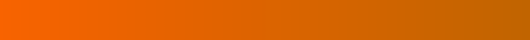

Published By Baishideng Publishing Group Inc

7041 Koll Center Parkway, Suite 160, Pleasanton, CA 94566, USA

Telephone: +1-925-2238242

Fax: +1-925-2238243

E-mail: bpgoffice@wjgnet.com

Help Desk:http://www.f6publishing.com/helpdesk

http://www.wjgnet.com

[figure not shown]

**© 2019 Baishideng Publishing Group Inc. All rights reserved.**